# Game-based second language vocabulary acquisition: A multivariate multi-level meta-Analysis

© Reza Norouzian

August 2025

# 1 Raw data and initial analyses

# 2 Data and analyses

To better understand the variables involved in the analyses (e.g., those used for estimating Hedges’ *g* effect sizes), the next Table provides a list of their names and definitions. (*Click on `Code` on the bottom right for the reproducible codes used in each section*).

```r
# We use the software package introduced by Norouzian (2021)
source("https://raw.githubusercontent.com/rnorouzian/m/refs/heads/master/r.r")

# We use the software package introduced by Norouzian & Bui (2024)
source("https://raw.githubusercontent.com/rnorouzian/i/master/3m.r")

library(googlesheets4)
library(knitr)
library(flextable)
library(kableExtra)
library(rmarkdown)

opts_chunk$set(message=FALSE, warning=FALSE, fig.align="center")


dat6 <- read_sheet("https://docs.google.com/spreadsheets/d/1onJm5n8N8cjxJdb-rzvR0DZpg7rcJmPVrHxbDncg2-k/edit?usp=sharing")


results <- readRDS("C:/Users/Reza/Desktop/Meta Games/Game/G.rds")

 moderators_abb_names <- names(results)

table_names <- c(
  "Time",
  "Game Type",
  "Vocab Dimension",
  "Word Unit",
  "Measure Type",
  "Proficiency",
  "Age Group",
  "Study Setting",
  "L1-L2 Orthographic Distance",
  "Region"
)

# A list of time and moderators interacting with time
LIST <- c("time", map(moderators_abb_names[-1], c, "time"))

effect_no <- setNames(map(LIST, ~effect_count(dat6, study, !!!syms(.),
                                              show0=FALSE, na.rm=TRUE,
                                              arrange_by="time",
                                              subset = time!="Posttest3")), table_names)

results <- setNames(results, table_names)
```

# 3 Definition of the additional variables beyond moderators

The additional variables beyond moderators

| Variable | Definition |
| --- | --- |
| study | Author(s) |
| year | Year of publication |
| gray | Gray literature binary identifier (i.e., research produced by less visible or well-known publishers or by organizations outside of the traditional commercial or academic publishing and distribution ch… |
| assign_type | Assignment of groups by class or by student |
| n_class | Total number of classes assigned to all groups |
| Nt | Total number of students in all classes assigned to treatments |
| Nc | Total number of students in all classes assigned to control |
| sample_id | Numerical index of the independent samples of participants |
| g | Effect size estimates before assign_type adjustment |
| v_g | Sampling variances before assign_type adjustment |
| g2 | Effect size estimates after assign_type adjustment |
| v_g2 | Sampling variances after assign_type adjustment |
| nT | Number of participants in each treatment group |
| mT | Mean of each treatment group |
| sdT | Standard deviation of each treatment group |
| nC | Number of participants in the control group |
| mC | Mean of the control group |
| sdC | Standard deviation of the control group |
| effect | Numerical index of each row |
| SE_egger | Modified standard error of Hedges' g for Egger's test purposes based on Pustejovsky and Rogers (2019) |

# 4 Display of data and preliminary descriptive analyses

Once again, *click on `Code` on the bottom right for the reproducible codes used in each section*.

# 5 Distribution Summary of Effect Sizes

```r
g <- dat6 %>%
  group_by(study) %>%
  summarise(n_gi = n()) %>%
  summarise(
    `No. of Studies` = n(),
    `No. of Effects` = sum(n_gi),
    `Min. Effects in Study` = min(n_gi),
    `Max. Effects in Study` = max(n_gi),
    `Median Effects in Study` = median(n_gi)
  ) %>% ungroup()


flextable(g) %>%
  autofit() %>% set_caption("Distribution Summary of Effect Sizes") %>% fontsize(size = 11, part = "all") %>%
  line_spacing(space = .6, part = "all")
```

Distribution Summary of Effect Sizes

| No. of Studies | No. of Effects | Min. Effects in Study | Max. Effects in Study | Median Effects in Study |
| --- | --- | --- | --- | --- |
| 60 | 167 | 1 | 12 | 2 |

# 6 Publication Bias

## 6.1 Funnel plot at study level

Figure 3 displays the studies’ individual effect size estimates aggregated at the study level. The dotted triangle indicates the boundaries for statistical significance on either side of the *null effect* (i.e., *no study-level effect in reality exists; 0*).

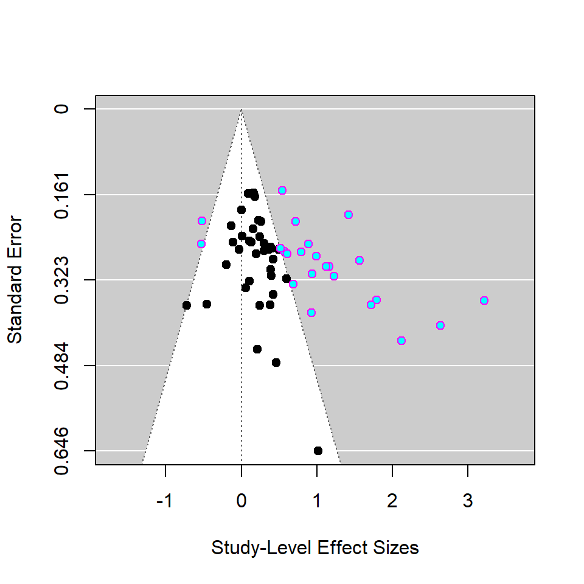

Figure 3. Contour-Enhanced Funnel Plot of Study-Level Effects

```r
###############################
# 3M publication bias detection
###############################

# Naturally existing dependence from previous section
Vs = with(dat6, impute_covariance_matrix(v_g2, study, r=.5,
                                        subgroup = sample_id))

# Magnitude of within-study correlations
rho <- 0.5

# Aggregate effects at Study level (level 3)
data_agg_study <-
  dat6 %>%
  escalc(data = ., yi = g2, vi = v_g2) %>%
  aggregate.escalc(cluster = study, rho = rho, weighted = FALSE)

# Contour plot at study level
g <- with(data_agg_study,
     contour_funnel(x = g2,
                    vi = v_g2, sig = TRUE,
                    xlab = "Study-Level Effect Sizes"))

box()
```

```r
invisible(NULL)

flextable(g) %>%
  autofit() %>% set_caption("Statistically significant study level effects") %>% fontsize(size = 11, part = "all") %>%
  line_spacing(space = .6, part = "all")
```

Statistically significant study level effects

| Total | Total(%) | Left | Left(%) | Right | Right(%) | Sig. |
| --- | --- | --- | --- | --- | --- | --- |
| 23 | 38.33 | 2 | 3.33 | 21 | 35 | 0.05 |

As can be seen, there are 21 effect size estimates aggregated at the study level that are statistically significant in magnitude and positive in direction. This value constitutes ~35% of the total number of study-level aggregate effect sizes in our meta-analysis. Arguably, such evidence does not seem to indicate a tendency for the game-based vocabulary acquisition literature to intentionally favor studies that, as a whole, have found positive and statistically significant effects from game-based L2 vocabulary acquisition. Thus, this form of publication bias at the study-level seems less likely.

## 6.2 Funnel plot at effect size level

Figure 4 displays the studies’ individual effect size estimates. As before, the dotted triangle indicates the boundaries for statistical significance on either side of the *null effect* (i.e., *no individual effect in reality exists; 0*).

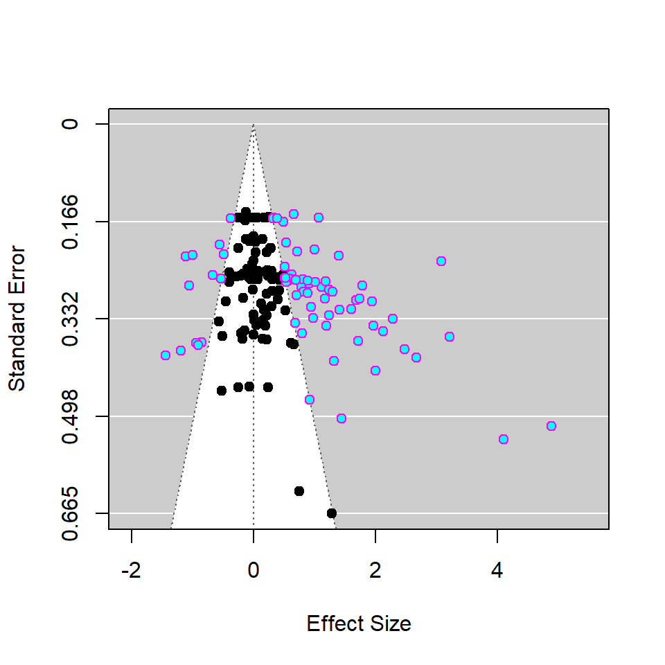

Figure 4. Contour-Enhanced Funnel Plot of Individual Effects

```r
# Contour plot at effect size level
g <- with(dat6,
      contour_funnel(x = g2,
                     vi = v_g2, sig = TRUE))

box()
```

```r
invisible(NULL)

flextable(g) %>%
  autofit() %>% set_caption("Statistically significant individual effects") %>% fontsize(size = 11, part = "all") %>%
  line_spacing(space = .6, part = "all")
```

Statistically significant individual effects

| Total | Total(%) | Left | Left(%) | Right | Right(%) | Sig. |
| --- | --- | --- | --- | --- | --- | --- |
| 73 | 43.71 | 13 | 7.78 | 60 | 35.93 | 0.05 |

As can be seen, there are 60 effect size estimates that are statistically significant in magnitude and positive in direction. This value constitutes ~35.93% percent of the total number of effect sizes in our meta-analysis. On the other hand, there are 13 effect size estimates that are statistically significant in magnitude and *negative* in direction. This value constitutes ~7.78% percent of the total number of effect sizes in our meta-analysis.

Arguably, the comparison at the effect size level could potentially suggest the possibility of *an imbalance* in the game-based L2 vocabulary acquisition literature in favor of the positive and statistically significant effects. However, given the lack of such an imbalance at the study-level and presence of multiple positive and statistically significant effects in the less visible literature, the trend seen at the effect size level might indicate a somewhat natural process that is not, for the most part, impacted by the publication industry’s policies as to which studies should be published and which ones should not in the game-based L2 vocabulary acquisition literature.

## 6.3 Egger’s test

We also conducted an Egger’s test ([Egger, Smith, Schneider, & Minder, 1997](https://doi.org/10.1136/bmj.315.7109.629)) of funnel plot symmetry. Using this test, we examined the extent to which the standard error (as a measure of precision) of the effect sizes collected from the game-based L2 vocabulary acquisition literature related to the effect sizes’ magnitude. If such a relationship and/or its estimate of intercept, with the latter sometimes referred to as a *precision-effect test (PET)*, rise to statistically significant levels, that could suggest asymmetry (and potentially publication bias) in the funnel plot of effect sizes.

```r
# Eggers test using the same naturally and statistically occurring dependence
ff = rma.mv(g2 ~ SE_egger, V = Vs,
            random = ~1|study/effect, data = dat6,
            dfs = "contain")

g <- results_rma(ff, drop_rows = 3:7, drop_cols = 9:10, tidy = TRUE)

flextable(dplyr::select(g, -Df)) %>%
  autofit() %>% set_caption("Egger's Test Results") %>% fontsize(size = 11, part = "all") %>%
  line_spacing(space = .6, part = "all")
```

Egger's Test Results

| Terms | Estimate | SE | t | p-value | Sig. | Lower | Upper |
| --- | --- | --- | --- | --- | --- | --- | --- |
| (Intercept) | 0.391 | 0.304 | 1.285 | 0.204 |  | -0.218 | 1.000 |
| SE_egger | 0.277 | 1.105 | 0.251 | 0.802 |  | -1.904 | 2.458 |

In our case, given that the p-value for the Egger’s test for the relationship in question (*b* = 0.277, *p* = 0.802; 95% CI[-1.904, 2.458]) and its estimate of intercept (*a* = 0.391, *p* = 0.204; 95% CI[-0.218, 1.000]) are both larger than 0.05, we concluded that our funnel plot is sufficiently symmetric and the likelihood of publication bias in the collected sample of game-based L2 vocabulary acquisition studies is small with the caveat that the *b* estimate has a relatively wide CI.

# 7 Inter-rater reliability (IRR)

```r
c_1 = read_sheet("https://docs.google.com/spreadsheets/d/1nZDy96tEmWYfmF2_SfvLIvwU4VNKBrFBixieuZs830M/edit?usp=sharing")

c_2 = read_sheet("https://docs.google.com/spreadsheets/d/1P2saXIsjNt844KRQ4ymFMJTS3ErzTzvmnL3s_lqwuLo/edit?usp=sharing")

g <- meta_rate(c_1, c_2, plot=FALSE,
          drop = c("formula","input_mode",
                   "valence","study_design",
                   "outcome","time"))

flextable(g) %>%
  autofit() %>% set_caption("Inter-Rater reliability for categorical moderators") %>%
  fontsize(size = 9.5, part = "all") %>%
  line_spacing(space = .6, part = "all")
```

Inter-Rater reliability for categorical moderators

| Moderator | Raw_Agreement | Fleiss_Kappa | S_Index | Lower | Upper | Conf_Level | Rows_Compared | Min_Cat | N_Coder | Study_Level |
| --- | --- | --- | --- | --- | --- | --- | --- | --- | --- | --- |
| age_general | 0.917 | 0.869 | 0.875 | 0.625 | 1.000 | 0.95 | 12 | Adolescents | 2 | Yes |
| assign.type | 1.000 | 1.000 | 1.000 | 1.000 | 1.000 | 0.95 | 12 | -- | 2 | Yes |
| L1 | 1.000 | 1.000 | 1.000 | 1.000 | 1.000 | 0.95 | 12 | -- | 2 | Yes |
| material_type | 1.000 | 1.000 | 1.000 | 1.000 | 1.000 | 0.95 | 12 | -- | 2 | Yes |
| measure | 0.571 | 0.375 | 0.429 | 0.190 | 0.667 | 0.95 | 28 | Mixed | 2 | No |
| prof | 1.000 | 1.000 | 1.000 | 1.000 | 1.000 | 0.95 | 12 | -- | 2 | Yes |
| region | 1.000 | 1.000 | 1.000 | 1.000 | 1.000 | 0.95 | 12 | -- | 2 | Yes |
| script_distance | 1.000 | 1.000 | 1.000 | 1.000 | 1.000 | 0.95 | 12 | -- | 2 | Yes |
| setting | 1.000 | 1.000 | 1.000 | 1.000 | 1.000 | 0.95 | 12 | -- | 2 | Yes |
| study_setting | 1.000 | 1.000 | 1.000 | 1.000 | 1.000 | 0.95 | 12 | -- | 2 | Yes |
| test_type | 1.000 | 1.000 | 1.000 | 1.000 | 1.000 | 0.95 | 12 | -- | 2 | Yes |
| true_experiment | 1.000 | 1.000 | 1.000 | 1.000 | 1.000 | 0.95 | 12 | -- | 2 | Yes |
| word_dimension | 1.000 | 1.000 | 1.000 | 1.000 | 1.000 | 0.95 | 28 | -- | 2 | No |
| word_unit | 1.000 | 1.000 | 1.000 | 1.000 | 1.000 | 0.95 | 12 | -- | 2 | Yes |

# 8 Results of analyses

In this section, we present the results of our analyses in two parts. In the first part, we present the synthesized effects at each time point. As mentioned in the manuscript, results based on a limited number of effects (**M**) and/or studies (**K**) should be ignored due to their unreliable nature.

Also presented in the first part is the $R^2$ test of heterogeneity. $R^2$ indicates the percentage of change in the total heterogeneity (between- and within the studies) in the true effects of game-based L2 vocabulary acquisition from a model without any MUTOS moderator (a null model) to that from a model that includes a set of MUTOS moderators of interest.

While necessary, the results presented in the first part may not by themselves immediately translate into evidence-based recommendations. This is because the descriptive (synthesized average effects) and the associated inferential results (CIs and p-values) simply denote how much effect at each measurement occasion exists and if that effect is reliably different from 0 at that point in time.

In the second part, we compare the changes that occurred in learners’ performance from one measurement occasion (baseline) to another (post-test) to specifically measure the potential learning *“gains”* that might have resulted from game-based L2 vocabulary acquisition treatments taking into account the methodological differences that differentiate the studies to varying degrees (see Table 2 in the manuscript for more details on moderators).

Because the second part allows us to measure the gains from game-based L2 vocabulary acquisition across more than one occasion, the results (i.e., synthesized average effects and their associated CIs and p-values) more immediately translate into evidence-based recommendations. To further facilitate such recommendations, in the second part we also measure a minimum expected benefit of using game-based L2 vocabulary acquisition presented in the universal metric of percentages.

## 8.1 Effects at each time

```r
rs <- results

invisible(lapply(table_names, \(i){


  cat(paste0("\n\n### ", i, "\n"))


g <- rs[[i]]$ems


g3 <- rs[[i]]$plot

g4 <- rs[[i]]$R2

print(g3)


tab <- g$table %>% mutate(.row_id = row_number())

merged_tab <- tab %>%
  left_join(effect_no[[i]], by = intersect(names(tab), names(effect_no[[i]]))) %>%
  arrange(.row_id) %>%                        # restore original order
  select(-.row_id) %>%                        # drop helper column
  rename(K = `n study`, M = `n effect`) %>%
  select(-Df)


print(kable(merged_tab, format = "simple", table.attr = "style='width:40%;'",
            caption = paste("3M results for",tolower(i),"categories")) %>%
  kable_styling(bootstrap_options = "bordered",
                full_width = TRUE, font_size = 9.5))


print(kable(g4 %>% rename(`Total Heterogeneity`=`Sigma(total)`, `Between-study Heterogeneity`=`Sigma(study)`, `Within-study Heterogeneity`=`Sigma(effect)`), format = "simple", table.attr = "style='width:40%;'",
            caption = paste("R2 test of heterogeneity for",tolower(i)) ) %>%
    add_footnote(c("Heterogeneity is in SD unit.",paste("The *p-value* indicates the statistical significance of the MUTOS moderators in the",i, "model *collectively*."))) %>%
  kable_styling(bootstrap_options = "bordered",
                full_width = TRUE, font_size = 9.5))

}))
```

### 8.1.1 Time

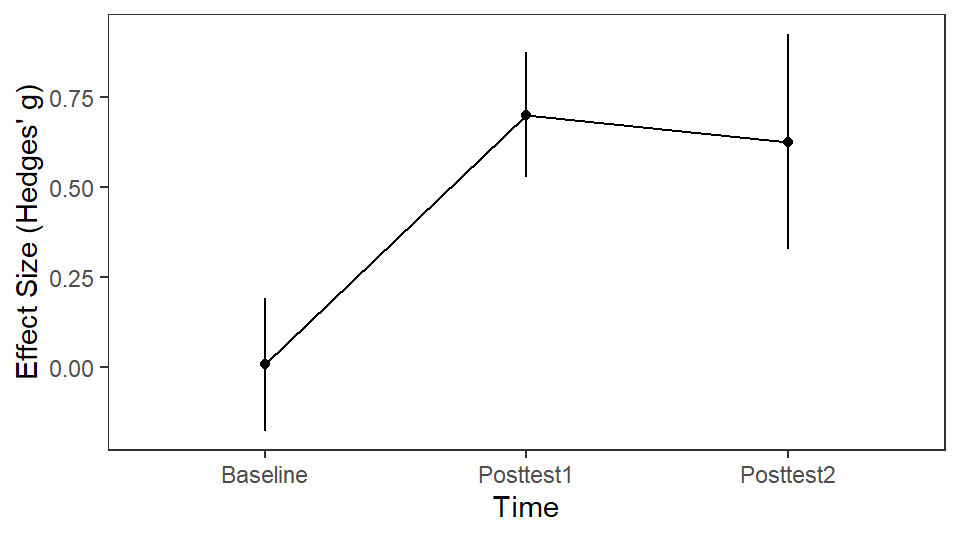

3M results for time categories

| time | Mean | SE | Lower | Upper | t | p-value | Sig. | K | M |
| --- | --- | --- | --- | --- | --- | --- | --- | --- | --- |
| Baseline | 0.007 | 0.092 | -0.178 | 0.192 | 0.080 | 0.937 |  | 47 | 63 |
| Posttest1 | 0.701 | 0.086 | 0.528 | 0.874 | 8.156 | 0.000 | *** | 58 | 81 |
| Posttest2 | 0.626 | 0.149 | 0.327 | 0.925 | 4.205 | 0.000 | *** | 13 | 20 |

R2 test of heterogeneity for time

| Model | Total Heterogeneity | Between-study Heterogeneity | Within-study Heterogeneity | p-value | R2 |
| --- | --- | --- | --- | --- | --- |
| No (M)UTOS | 0.774 | 0.339 | 0.696 |  |  |
| Time | 0.613 | 0.343 | 0.507 | 0.048 | 20.830% |

**Note:** <sup>a</sup> Heterogeneity is in SD unit. <sup>b</sup> The *p-value* indicates the statistical significance of the MUTOS moderators in the Time model *collectively*.

### 8.1.2 Game Type

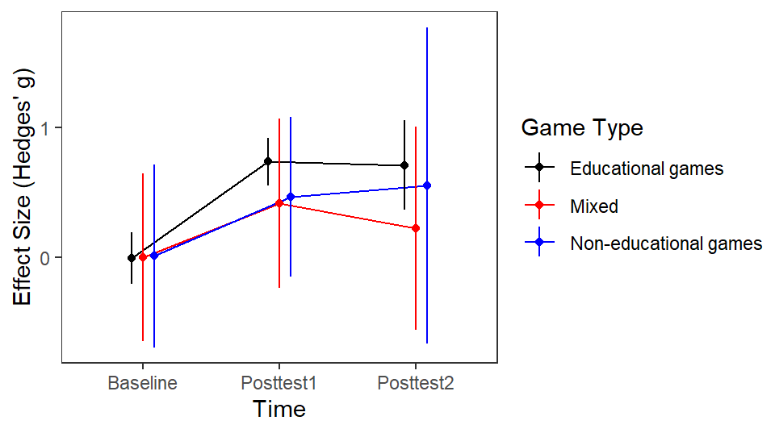

3M results for game type categories

| treat_grp | time | Mean | SE | Lower | Upper | t | p-value | Sig. | K | M |
| --- | --- | --- | --- | --- | --- | --- | --- | --- | --- | --- |
| Educational games | Baseline | -0.005 | 0.100 | -0.205 | 0.196 | -0.046 | 0.963 |  | 43 | 53 |
| Mixed | Baseline | 0.001 | 0.322 | -0.649 | 0.651 | 0.003 | 0.998 |  | 4 | 7 |
| Non-educational games | Baseline | 0.010 | 0.349 | -0.694 | 0.714 | 0.029 | 0.977 |  | 3 | 3 |
| Educational games | Posttest1 | 0.739 | 0.092 | 0.554 | 0.925 | 8.036 | 0.000 | *** | 54 | 70 |
| Mixed | Posttest1 | 0.417 | 0.323 | -0.234 | 1.069 | 1.291 | 0.203 |  | 4 | 7 |
| Non-educational games | Posttest1 | 0.469 | 0.305 | -0.146 | 1.085 | 1.538 | 0.131 |  | 4 | 4 |
| Educational games | Posttest2 | 0.712 | 0.171 | 0.367 | 1.058 | 4.156 | 0.000 | *** | 12 | 15 |
| Mixed | Posttest2 | 0.226 | 0.389 | -0.558 | 1.010 | 0.581 | 0.564 |  | 1 | 4 |
| Non-educational games | Posttest2 | 0.554 | 0.606 | -0.667 | 1.775 | 0.915 | 0.365 |  | 1 | 1 |

R2 test of heterogeneity for game type

| Model | Total Heterogeneity | Between-study Heterogeneity | Within-study Heterogeneity | p-value | R2 |
| --- | --- | --- | --- | --- | --- |
| No (M)UTOS | 0.774 | 0.339 | 0.696 |  |  |
| Game Type | 0.617 | 0.334 | 0.519 | 0.000 | 20.260% |

**Note:** <sup>a</sup> Heterogeneity is in SD unit. <sup>b</sup> The *p-value* indicates the statistical significance of the MUTOS moderators in the Game Type model *collectively*.

### 8.1.3 Vocab Dimension

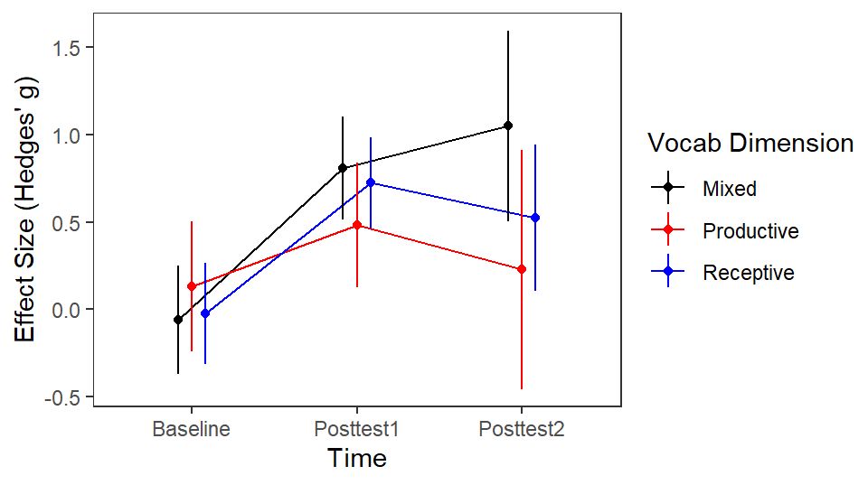

3M results for vocab dimension categories

| word_dimension | time | Mean | SE | Lower | Upper | t | p-value | Sig. | K | M |
| --- | --- | --- | --- | --- | --- | --- | --- | --- | --- | --- |
| Mixed | Baseline | -0.059 | 0.154 | -0.371 | 0.252 | -0.385 | 0.702 |  | 18 | 22 |
| Productive | Baseline | 0.132 | 0.184 | -0.240 | 0.503 | 0.715 | 0.479 |  | 11 | 15 |
| Receptive | Baseline | -0.024 | 0.144 | -0.313 | 0.266 | -0.165 | 0.870 |  | 19 | 26 |
| Mixed | Posttest1 | 0.808 | 0.146 | 0.515 | 1.102 | 5.552 | 0.000 | *** | 22 | 25 |
| Productive | Posttest1 | 0.485 | 0.177 | 0.129 | 0.841 | 2.745 | 0.009 | ** | 13 | 20 |
| Receptive | Posttest1 | 0.725 | 0.130 | 0.464 | 0.986 | 5.596 | 0.000 | *** | 24 | 36 |
| Mixed | Posttest2 | 1.051 | 0.270 | 0.506 | 1.596 | 3.891 | 0.000 | *** | 5 | 6 |
| Productive | Posttest2 | 0.228 | 0.339 | -0.456 | 0.912 | 0.671 | 0.506 |  | 2 | 4 |
| Receptive | Posttest2 | 0.523 | 0.208 | 0.105 | 0.942 | 2.521 | 0.015 | * | 6 | 10 |

R2 test of heterogeneity for vocab dimension

| Model | Total Heterogeneity | Between-study Heterogeneity | Within-study Heterogeneity | p-value | R2 |
| --- | --- | --- | --- | --- | --- |
| No (M)UTOS | 0.774 | 0.339 | 0.696 |  |  |
| Vocab Dimension | 0.613 | 0.349 | 0.505 | 0.033 | 20.725% |

**Note:** <sup>a</sup> Heterogeneity is in SD unit. <sup>b</sup> The *p-value* indicates the statistical significance of the MUTOS moderators in the Vocab Dimension model *collectively*.

### 8.1.4 Word Unit

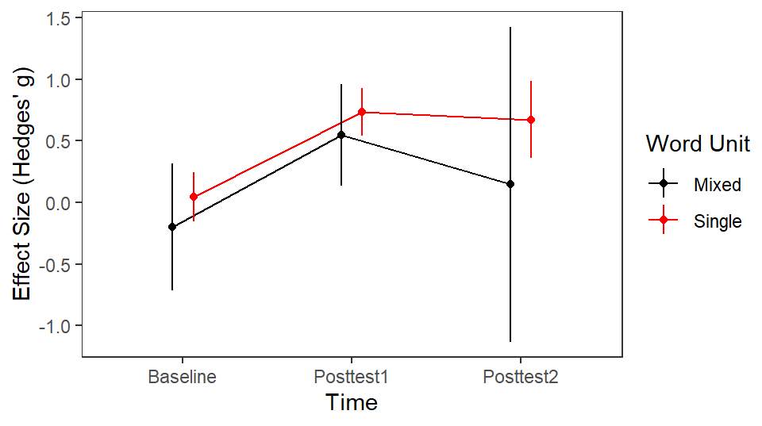

3M results for word unit categories

| word_unit | time | Mean | SE | Lower | Upper | t | p-value | Sig. | K | M |
| --- | --- | --- | --- | --- | --- | --- | --- | --- | --- | --- |
| Mixed | Baseline | -0.200 | 0.255 | -0.714 | 0.313 | -0.785 | 0.436 |  | 5 | 7 |
| Single | Baseline | 0.044 | 0.099 | -0.156 | 0.244 | 0.439 | 0.662 |  | 42 | 56 |
| Mixed | Posttest1 | 0.548 | 0.203 | 0.138 | 0.957 | 2.692 | 0.010 | ** | 9 | 13 |
| Single | Posttest1 | 0.735 | 0.095 | 0.543 | 0.926 | 7.723 | 0.000 | *** | 49 | 68 |
| Mixed | Posttest2 | 0.146 | 0.634 | -1.131 | 1.423 | 0.231 | 0.819 |  | 1 | 1 |
| Single | Posttest2 | 0.672 | 0.155 | 0.360 | 0.984 | 4.331 | 0.000 | *** | 12 | 19 |

R2 test of heterogeneity for word unit

| Model | Total Heterogeneity | Between-study Heterogeneity | Within-study Heterogeneity | p-value | R2 |
| --- | --- | --- | --- | --- | --- |
| No (M)UTOS | 0.774 | 0.339 | 0.696 |  |  |
| Word Unit | 0.617 | 0.346 | 0.511 | 0.136 | 20.213% |

**Note:** <sup>a</sup> Heterogeneity is in SD unit. <sup>b</sup> The *p-value* indicates the statistical significance of the MUTOS moderators in the Word Unit model *collectively*.

### 8.1.5 Measure Type

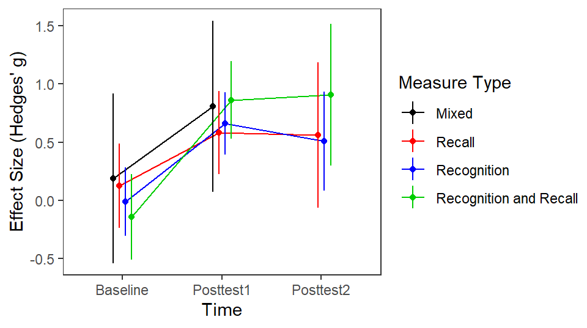

3M results for measure type categories

| measure | time | Mean | SE | Lower | Upper | t | p-value | Sig. | K | M |
| --- | --- | --- | --- | --- | --- | --- | --- | --- | --- | --- |
| Mixed | Baseline | 0.190 | 0.360 | -0.537 | 0.918 | 0.528 | 0.600 |  | 3 | 5 |
| Recall | Baseline | 0.126 | 0.180 | -0.236 | 0.489 | 0.703 | 0.486 |  | 12 | 16 |
| Recognition | Baseline | -0.011 | 0.145 | -0.303 | 0.282 | -0.076 | 0.940 |  | 20 | 27 |
| Recognition and Recall | Baseline | -0.141 | 0.182 | -0.510 | 0.227 | -0.775 | 0.443 |  | 13 | 15 |
| Mixed | Posttest1 | 0.806 | 0.363 | 0.072 | 1.540 | 2.218 | 0.032 | * | 3 | 5 |
| Recall | Posttest1 | 0.582 | 0.176 | 0.227 | 0.937 | 3.308 | 0.002 | ** | 14 | 19 |
| Recognition | Posttest1 | 0.659 | 0.132 | 0.393 | 0.925 | 5.006 | 0.000 | *** | 24 | 37 |
| Recognition and Recall | Posttest1 | 0.862 | 0.166 | 0.527 | 1.196 | 5.198 | 0.000 | *** | 18 | 20 |
| Recall | Posttest2 | 0.561 | 0.309 | -0.062 | 1.185 | 1.818 | 0.076 | . | 3 | 5 |
| Recognition | Posttest2 | 0.510 | 0.210 | 0.086 | 0.933 | 2.431 | 0.020 | * | 6 | 10 |
| Recognition and Recall | Posttest2 | 0.906 | 0.300 | 0.300 | 1.511 | 3.020 | 0.004 | ** | 4 | 5 |

R2 test of heterogeneity for measure type

| Model | Total Heterogeneity | Between-study Heterogeneity | Within-study Heterogeneity | p-value | R2 |
| --- | --- | --- | --- | --- | --- |
| No (M)UTOS | 0.774 | 0.339 | 0.696 |  |  |
| Measure Type | 0.623 | 0.359 | 0.510 | 0.171 | 19.430% |

**Note:** <sup>a</sup> Heterogeneity is in SD unit. <sup>b</sup> The *p-value* indicates the statistical significance of the MUTOS moderators in the Measure Type model *collectively*.

### 8.1.6 Proficiency

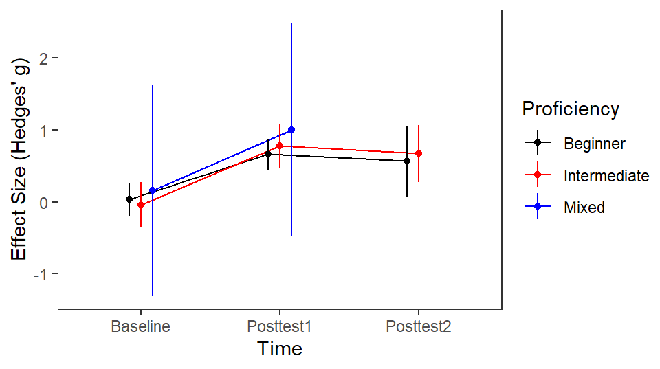

3M results for proficiency categories

| prof | time | Mean | SE | Lower | Upper | t | p-value | Sig. | K | M |
| --- | --- | --- | --- | --- | --- | --- | --- | --- | --- | --- |
| Beginner | Baseline | 0.030 | 0.117 | -0.207 | 0.266 | 0.254 | 0.800 |  | 27 | 39 |
| Intermediate | Baseline | -0.041 | 0.156 | -0.356 | 0.274 | -0.262 | 0.794 |  | 19 | 23 |
| Mixed | Baseline | 0.162 | 0.730 | -1.308 | 1.633 | 0.222 | 0.825 |  | 1 | 1 |
| Beginner | Posttest1 | 0.660 | 0.107 | 0.445 | 0.875 | 6.192 | 0.000 | *** | 36 | 54 |
| Intermediate | Posttest1 | 0.774 | 0.151 | 0.470 | 1.078 | 5.128 | 0.000 | *** | 21 | 26 |
| Mixed | Posttest1 | 0.998 | 0.734 | -0.481 | 2.478 | 1.360 | 0.181 |  | 1 | 1 |
| Beginner | Posttest2 | 0.566 | 0.244 | 0.076 | 1.057 | 2.326 | 0.025 | * | 4 | 7 |
| Intermediate | Posttest2 | 0.669 | 0.197 | 0.272 | 1.066 | 3.395 | 0.001 | ** | 9 | 13 |

R2 test of heterogeneity for proficiency

| Model | Total Heterogeneity | Between-study Heterogeneity | Within-study Heterogeneity | p-value | R2 |
| --- | --- | --- | --- | --- | --- |
| No (M)UTOS | 0.774 | 0.339 | 0.696 |  |  |
| Proficiency | 0.622 | 0.348 | 0.516 | 0.000 | 19.580% |

**Note:** <sup>a</sup> Heterogeneity is in SD unit. <sup>b</sup> The *p-value* indicates the statistical significance of the MUTOS moderators in the Proficiency model *collectively*.

### 8.1.7 Age Group

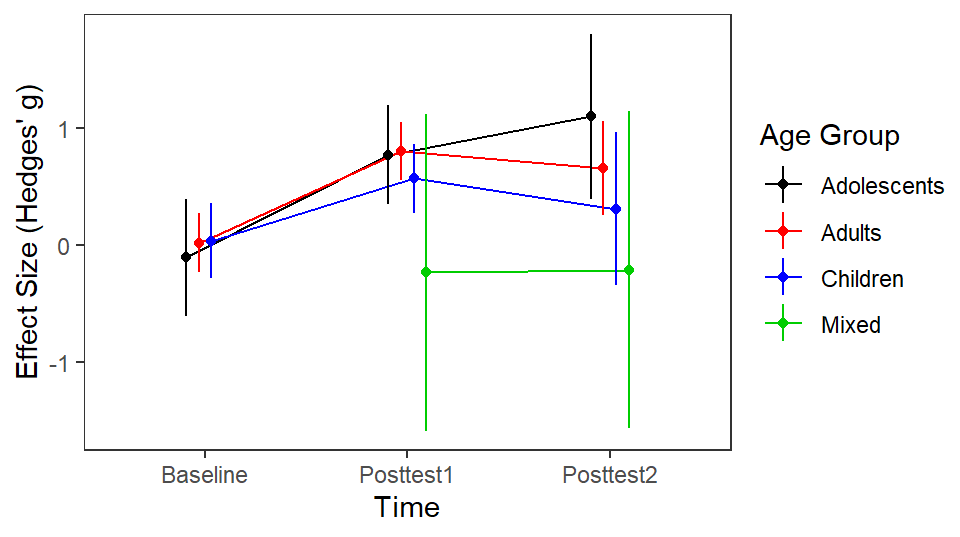

3M results for age group categories

| age_general | time | Mean | SE | Lower | Upper | t | p-value | Sig. | K | M |
| --- | --- | --- | --- | --- | --- | --- | --- | --- | --- | --- |
| Adolescents | Baseline | -0.108 | 0.249 | -0.610 | 0.394 | -0.434 | 0.666 |  | 6 | 8 |
| Adults | Baseline | 0.018 | 0.126 | -0.236 | 0.272 | 0.144 | 0.886 |  | 27 | 33 |
| Children | Baseline | 0.036 | 0.160 | -0.287 | 0.359 | 0.223 | 0.824 |  | 14 | 22 |
| Adolescents | Posttest1 | 0.772 | 0.210 | 0.347 | 1.196 | 3.672 | 0.001 | *** | 9 | 13 |
| Adults | Posttest1 | 0.806 | 0.123 | 0.559 | 1.054 | 6.575 | 0.000 | *** | 30 | 40 |
| Children | Posttest1 | 0.569 | 0.147 | 0.272 | 0.866 | 3.870 | 0.000 | *** | 18 | 27 |
| Mixed | Posttest1 | -0.235 | 0.672 | -1.592 | 1.121 | -0.350 | 0.728 |  | 1 | 1 |
| Adolescents | Posttest2 | 1.102 | 0.350 | 0.396 | 1.808 | 3.152 | 0.003 | ** | 3 | 4 |
| Adults | Posttest2 | 0.659 | 0.199 | 0.256 | 1.061 | 3.305 | 0.002 | ** | 8 | 11 |
| Children | Posttest2 | 0.311 | 0.325 | -0.345 | 0.967 | 0.956 | 0.345 |  | 1 | 4 |
| Mixed | Posttest2 | -0.212 | 0.672 | -1.568 | 1.145 | -0.315 | 0.754 |  | 1 | 1 |

R2 test of heterogeneity for age group

| Model | Total Heterogeneity | Between-study Heterogeneity | Within-study Heterogeneity | p-value | R2 |
| --- | --- | --- | --- | --- | --- |
| No (M)UTOS | 0.774 | 0.339 | 0.696 |  |  |
| Age Group | 0.613 | 0.343 | 0.508 | 0.000 | 20.834% |

**Note:** <sup>a</sup> Heterogeneity is in SD unit. <sup>b</sup> The *p-value* indicates the statistical significance of the MUTOS moderators in the Age Group model *collectively*.

### 8.1.8 Study Setting

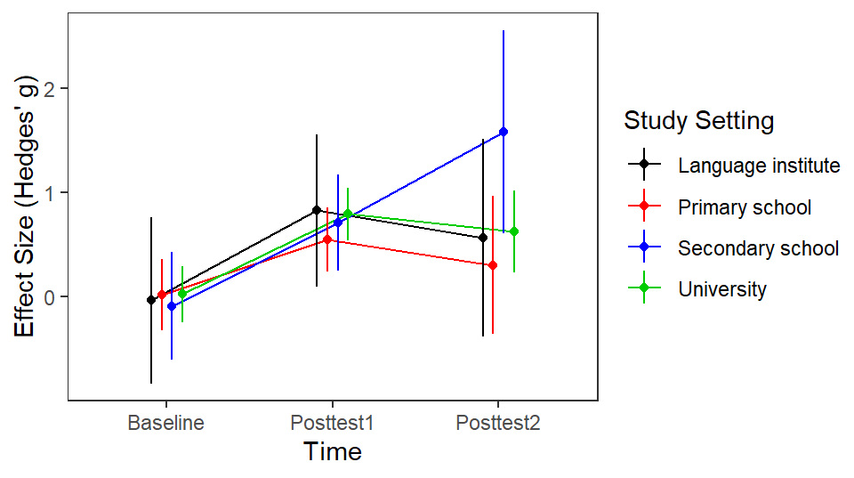

3M results for study setting categories

| study_setting | time | Mean | SE | Lower | Upper | t | p-value | Sig. | K | M |
| --- | --- | --- | --- | --- | --- | --- | --- | --- | --- | --- |
| Language institute | Baseline | -0.033 | 0.394 | -0.828 | 0.763 | -0.083 | 0.934 |  | 3 | 3 |
| Primary school | Baseline | 0.021 | 0.168 | -0.318 | 0.360 | 0.124 | 0.902 |  | 13 | 21 |
| Secondary school | Baseline | -0.087 | 0.255 | -0.602 | 0.428 | -0.341 | 0.735 |  | 6 | 8 |
| University | Baseline | 0.025 | 0.131 | -0.240 | 0.289 | 0.188 | 0.852 |  | 25 | 31 |
| Language institute | Posttest1 | 0.826 | 0.361 | 0.096 | 1.555 | 2.288 | 0.028 | * | 4 | 4 |
| Primary school | Posttest1 | 0.549 | 0.153 | 0.239 | 0.859 | 3.576 | 0.001 | *** | 17 | 26 |
| Secondary school | Posttest1 | 0.712 | 0.228 | 0.251 | 1.174 | 3.120 | 0.003 | ** | 8 | 11 |
| University | Posttest1 | 0.794 | 0.125 | 0.541 | 1.047 | 6.354 | 0.000 | *** | 29 | 40 |
| Language institute | Posttest2 | 0.567 | 0.469 | -0.381 | 1.515 | 1.210 | 0.234 |  | 2 | 2 |
| Primary school | Posttest2 | 0.303 | 0.327 | -0.357 | 0.964 | 0.928 | 0.359 |  | 1 | 4 |
| Secondary school | Posttest2 | 1.579 | 0.481 | 0.607 | 2.550 | 3.284 | 0.002 | ** | 2 | 2 |
| University | Posttest2 | 0.627 | 0.195 | 0.233 | 1.020 | 3.219 | 0.003 | ** | 8 | 12 |

R2 test of heterogeneity for study setting

| Model | Total Heterogeneity | Between-study Heterogeneity | Within-study Heterogeneity | p-value | R2 |
| --- | --- | --- | --- | --- | --- |
| No (M)UTOS | 0.774 | 0.339 | 0.696 |  |  |
| Study Setting | 0.621 | 0.362 | 0.505 | 0.000 | 19.722% |

**Note:** <sup>a</sup> Heterogeneity is in SD unit. <sup>b</sup> The *p-value* indicates the statistical significance of the MUTOS moderators in the Study Setting model *collectively*.

### 8.1.9 L1-L2 Orthographic Distance

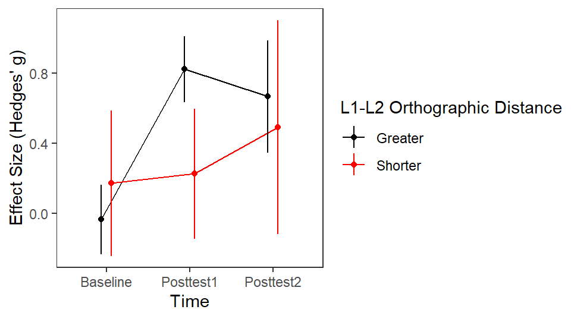

3M results for l1-l2 orthographic distance categories

| script_distance | time | Mean | SE | Lower | Upper | t | p-value | Sig. | K | M |
| --- | --- | --- | --- | --- | --- | --- | --- | --- | --- | --- |
| Greater | Baseline | -0.035 | 0.098 | -0.232 | 0.163 | -0.353 | 0.725 |  | 42 | 51 |
| Shorter | Baseline | 0.172 | 0.206 | -0.242 | 0.586 | 0.835 | 0.408 |  | 6 | 12 |
| Greater | Posttest1 | 0.822 | 0.093 | 0.635 | 1.010 | 8.847 | 0.000 | *** | 50 | 65 |
| Shorter | Posttest1 | 0.227 | 0.185 | -0.145 | 0.598 | 1.228 | 0.226 |  | 9 | 16 |
| Greater | Posttest2 | 0.667 | 0.159 | 0.347 | 0.986 | 4.203 | 0.000 | *** | 11 | 16 |
| Shorter | Posttest2 | 0.492 | 0.303 | -0.118 | 1.101 | 1.625 | 0.111 |  | 3 | 4 |

R2 test of heterogeneity for l1-l2 orthographic distance

| Model | Total Heterogeneity | Between-study Heterogeneity | Within-study Heterogeneity | p-value | R2 |
| --- | --- | --- | --- | --- | --- |
| No (M)UTOS | 0.774 | 0.339 | 0.696 |  |  |
| L1-L2 Orthographic Distance | 0.592 | 0.339 | 0.485 | 0.172 | 23.511% |

**Note:** <sup>a</sup> Heterogeneity is in SD unit. <sup>b</sup> The *p-value* indicates the statistical significance of the MUTOS moderators in the L1-L2 Orthographic Distance model *collectively*.

### 8.1.10 Region

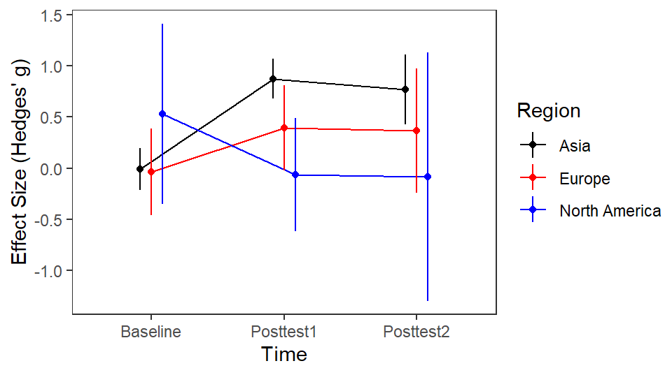

3M results for region categories

| region | time | Mean | SE | Lower | Upper | t | p-value | Sig. | K | M |
| --- | --- | --- | --- | --- | --- | --- | --- | --- | --- | --- |
| Asia | Baseline | -0.011 | 0.101 | -0.215 | 0.192 | -0.112 | 0.912 |  | 39 | 46 |
| Europe | Baseline | -0.036 | 0.211 | -0.461 | 0.389 | -0.172 | 0.864 |  | 6 | 13 |
| North America | Baseline | 0.530 | 0.437 | -0.350 | 1.411 | 1.214 | 0.231 |  | 2 | 4 |
| Asia | Posttest1 | 0.874 | 0.096 | 0.680 | 1.068 | 9.078 | 0.000 | *** | 46 | 57 |
| Europe | Posttest1 | 0.395 | 0.207 | -0.023 | 0.812 | 1.906 | 0.063 | . | 7 | 13 |
| North America | Posttest1 | -0.063 | 0.274 | -0.617 | 0.490 | -0.230 | 0.819 |  | 5 | 11 |
| Asia | Posttest2 | 0.767 | 0.169 | 0.427 | 1.108 | 4.549 | 0.000 | *** | 10 | 14 |
| Europe | Posttest2 | 0.366 | 0.301 | -0.241 | 0.972 | 1.216 | 0.231 |  | 2 | 5 |
| North America | Posttest2 | -0.082 | 0.603 | -1.298 | 1.133 | -0.137 | 0.892 |  | 1 | 1 |

R2 test of heterogeneity for region

| Model | Total Heterogeneity | Between-study Heterogeneity | Within-study Heterogeneity | p-value | R2 |
| --- | --- | --- | --- | --- | --- |
| No (M)UTOS | 0.774 | 0.339 | 0.696 |  |  |
| Region | 0.579 | 0.333 | 0.474 | 0.000 | 25.132% |

**Note:** <sup>a</sup> Heterogeneity is in SD unit. <sup>b</sup> The *p-value* indicates the statistical significance of the MUTOS moderators in the Region model *collectively*.

## 8.2 Learning Gains

```r
rs <- results

invisible(lapply(table_names, \(i){


  cat(paste0("\n\n### ", i, "\n"))


g <- rs[[i]]$ems

# Effects
gains <- if(i=="Time") contrast_rma(g, list("Gain1(Posttest 1 - Baseline)" =c(2,-1))) else contrast_rma(g, brief = TRUE, pretest_name = "Baseline",
                                                                                                        posttest_base_name = "Posttest")


print(kable(dplyr::select(gains$table, -Df),format = "simple", table.attr = "style='width:40%;'",
            caption = paste("Learning gains for", tolower(i))) %>%
  kable_styling(bootstrap_options = "bordered",
                full_width = TRUE, font_size = 9.5))


no <- i != c("Time")

if(no) gain_dif <- contrast_rma(g, gain_dif = TRUE, brief = TRUE, gain_dif_type = "same",
                                pretest_name = "Baseline", posttest_base_name = "Posttest")

if(no) print(kable(dplyr::select(gain_dif$table, -Df),format = "simple", table.attr = "style='width:40%;'",
            caption = paste("Differences in learning gains for", tolower(i))) %>%
  kable_styling(bootstrap_options = "bordered",
                full_width = TRUE, font_size = 9.5))


# Percentages
gain_prob <- prob_rma(gains, gain=TRUE, target_effect=.2)

print(kable(gain_prob,format = "simple", table.attr = "style='width:40%;'",
            caption = paste("Minimum learning gain percentage for", tolower(i))) %>%
  kable_styling(bootstrap_options = "bordered",
                full_width = TRUE, font_size = 9.5))

}))
```

### 8.2.1 Time

Learning gains for time

| Contrast | Estimate | SE | Lower | Upper | t | p-value | Sig. |
| --- | --- | --- | --- | --- | --- | --- | --- |
| Gain1(Posttest 1 - Baseline) | 0.694 | 0.098 | 0.498 | 0.890 | 7.106 | 0.000 | *** |

Minimum learning gain percentage for time

| Term | Target_Effect | Probability | Min | Max |
| --- | --- | --- | --- | --- |
| Gain1(Posttest 1 - Baseline) | 0.2 or larger | 68.81% | 60.73% | 77.10% |

### 8.2.2 Game Type

Learning gains for game type

| Contrast | Estimate | SE | Lower | Upper | t | p-value | Sig. |
| --- | --- | --- | --- | --- | --- | --- | --- |
| Gain1(Educational games) | 0.744 | 0.108 | 0.526 | 0.962 | 6.883 | 0.000 | *** |
| Gain2(Educational games) | 0.717 | 0.180 | 0.353 | 1.081 | 3.974 | 0.000 | *** |
| Gain1(Mixed) | 0.416 | 0.309 | -0.208 | 1.040 | 1.345 | 0.186 |  |
| Gain2(Mixed) | 0.225 | 0.355 | -0.491 | 0.940 | 0.634 | 0.530 |  |
| Gain1(Non-educational games) | 0.459 | 0.426 | -0.399 | 1.318 | 1.079 | 0.287 |  |
| Gain2(Non-educational games) | 0.544 | 0.676 | -0.819 | 1.906 | 0.805 | 0.425 |  |

Differences in learning gains for game type

| Contrast | Estimate | SE | Lower | Upper | t | p-value | Sig. |
| --- | --- | --- | --- | --- | --- | --- | --- |
| Gain1(Educational games) - Gain1(Mixed) | 0.327 | 0.328 | -0.333 | 0.988 | 0.999 | 0.323 |  |
| Gain1(Educational games) - Gain1(Non-educational games) | 0.284 | 0.438 | -0.599 | 1.168 | 0.650 | 0.519 |  |
| Gain2(Educational games) - Gain2(Mixed) | 0.492 | 0.398 | -0.310 | 1.295 | 1.237 | 0.223 |  |
| Gain2(Educational games) - Gain2(Non-educational games) | 0.173 | 0.694 | -1.226 | 1.573 | 0.250 | 0.804 |  |
| Gain1(Mixed) - Gain1(Non-educational games) | -0.043 | 0.526 | -1.104 | 1.018 | -0.082 | 0.935 |  |
| Gain2(Mixed) - Gain2(Non-educational games) | -0.319 | 0.764 | -1.860 | 1.222 | -0.417 | 0.679 |  |

Minimum learning gain percentage for game type

| Term | Target_Effect | Probability | Min | Max |
| --- | --- | --- | --- | --- |
| Gain1(Educational games) | 0.2 or larger | 70.33% | 61.56% | 79.16% |
| Gain2(Educational games) | 0.2 or larger | 69.41% | 55.48% | 82.61% |
| Gain1(Mixed) | 0.2 or larger | 58.40% | 35.65% | 81.47% |
| Gain2(Mixed) | 0.2 or larger | 50.98% | 26.67% | 78.49% |
| Gain1(Non-educational games) | 0.2 or larger | 60.04% | 29.46% | 88.33% |
| Gain2(Non-educational games) | 0.2 or larger | 63.22% | 17.92% | 96.55% |

### 8.2.3 Vocab Dimension

Learning gains for vocab dimension

| Contrast | Estimate | SE | Lower | Upper | t | p-value | Sig. |
| --- | --- | --- | --- | --- | --- | --- | --- |
| Gain1(Mixed) | 0.868 | 0.166 | 0.533 | 1.203 | 5.222 | 0.000 | *** |
| Gain2(Mixed) | 1.111 | 0.279 | 0.547 | 1.674 | 3.973 | 0.000 | *** |
| Gain1(Productive) | 0.353 | 0.197 | -0.045 | 0.751 | 1.788 | 0.081 | . |
| Gain2(Productive) | 0.096 | 0.340 | -0.590 | 0.782 | 0.283 | 0.779 |  |
| Gain1(Receptive) | 0.749 | 0.151 | 0.444 | 1.053 | 4.955 | 0.000 | *** |
| Gain2(Receptive) | 0.547 | 0.220 | 0.104 | 0.990 | 2.488 | 0.017 | * |

Differences in learning gains for vocab dimension

| Contrast | Estimate | SE | Lower | Upper | t | p-value | Sig. |
| --- | --- | --- | --- | --- | --- | --- | --- |
| Gain1(Mixed) - Gain1(Productive) | 0.515 | 0.258 | -0.005 | 1.035 | 1.996 | 0.052 | . |
| Gain1(Mixed) - Gain1(Receptive) | 0.119 | 0.225 | -0.334 | 0.572 | 0.531 | 0.598 |  |
| Gain2(Mixed) - Gain2(Productive) | 1.014 | 0.440 | 0.127 | 1.902 | 2.305 | 0.026 | * |
| Gain2(Mixed) - Gain2(Receptive) | 0.564 | 0.356 | -0.154 | 1.281 | 1.585 | 0.120 |  |
| Gain1(Productive) - Gain1(Receptive) | -0.396 | 0.248 | -0.897 | 0.105 | -1.593 | 0.119 |  |
| Gain2(Productive) - Gain2(Receptive) | -0.451 | 0.405 | -1.267 | 0.365 | -1.114 | 0.271 |  |

Minimum learning gain percentage for vocab dimension

| Term | Target_Effect | Probability | Min | Max |
| --- | --- | --- | --- | --- |
| Gain1(Mixed) | 0.2 or larger | 74.69% | 61.96% | 86.07% |
| Gain2(Mixed) | 0.2 or larger | 81.77% | 62.45% | 94.43% |
| Gain1(Productive) | 0.2 or larger | 56.05% | 41.14% | 72.41% |
| Gain2(Productive) | 0.2 or larger | 45.88% | 23.51% | 73.52% |
| Gain1(Receptive) | 0.2 or larger | 70.76% | 58.83% | 82.16% |
| Gain2(Receptive) | 0.2 or larger | 63.51% | 46.50% | 80.32% |

### 8.2.4 Word Unit

Learning gains for word unit

| Contrast | Estimate | SE | Lower | Upper | t | p-value | Sig. |
| --- | --- | --- | --- | --- | --- | --- | --- |
| Gain1(Mixed) | 0.748 | 0.267 | 0.211 | 1.285 | 2.805 | 0.007 | ** |
| Gain2(Mixed) | 0.347 | 0.673 | -1.008 | 1.701 | 0.515 | 0.609 |  |
| Gain1(Single) | 0.691 | 0.106 | 0.478 | 0.904 | 6.519 | 0.000 | *** |
| Gain2(Single) | 0.628 | 0.160 | 0.307 | 0.950 | 3.934 | 0.000 | *** |

Differences in learning gains for word unit

| Contrast | Estimate | SE | Lower | Upper | t | p-value | Sig. |
| --- | --- | --- | --- | --- | --- | --- | --- |
| Gain1(Mixed) - Gain1(Single) | 0.057 | 0.287 | -0.521 | 0.635 | 0.199 | 0.843 |  |
| Gain2(Mixed) - Gain2(Single) | -0.282 | 0.692 | -1.675 | 1.111 | -0.407 | 0.686 |  |

Minimum learning gain percentage for word unit

| Term | Target_Effect | Probability | Min | Max |
| --- | --- | --- | --- | --- |
| Gain1(Mixed) | 0.2 or larger | 70.61% | 50.40% | 87.77% |
| Gain2(Mixed) | 0.2 or larger | 55.78% | 13.58% | 94.62% |
| Gain1(Single) | 0.2 or larger | 68.64% | 59.99% | 77.48% |
| Gain2(Single) | 0.2 or larger | 66.40% | 53.88% | 78.94% |

### 8.2.5 Measure Type

Learning gains for measure type

|  | Contrast | Estimate | SE | Lower | Upper | t | p-value | Sig. |
| --- | --- | --- | --- | --- | --- | --- | --- | --- |
| 1 | Gain1(Mixed) | 0.616 | 0.351 | -0.093 | 1.324 | 1.755 | 0.087 | . |
| 3 | Gain1(Recall) | 0.456 | 0.194 | 0.064 | 0.848 | 2.347 | 0.024 | * |
| 4 | Gain2(Recall) | 0.435 | 0.312 | -0.194 | 1.064 | 1.397 | 0.170 |  |
| 5 | Gain1(Recognition and Recall) | 1.003 | 0.195 | 0.609 | 1.397 | 5.136 | 0.000 | *** |
| 6 | Gain2(Recognition and Recall) | 1.047 | 0.312 | 0.418 | 1.676 | 3.360 | 0.002 | ** |
| 7 | Gain1(Recognition) | 0.670 | 0.153 | 0.360 | 0.980 | 4.370 | 0.000 | *** |
| 8 | Gain2(Recognition) | 0.521 | 0.222 | 0.072 | 0.969 | 2.342 | 0.024 | * |

Differences in learning gains for measure type

|  | Contrast | Estimate | SE | Lower | Upper | t | p-value | Sig. |
| --- | --- | --- | --- | --- | --- | --- | --- | --- |
| 1 | Gain1(Mixed) - Gain1(Recall) | 0.160 | 0.401 | -0.650 | 0.970 | 0.399 | 0.692 |  |
| 2 | Gain1(Mixed) - Gain1(Recognition and Recall) | -0.387 | 0.402 | -1.198 | 0.424 | -0.964 | 0.341 |  |
| 3 | Gain1(Mixed) - Gain1(Recognition) | -0.054 | 0.383 | -0.827 | 0.719 | -0.141 | 0.888 |  |
| 7 | Gain1(Recall) - Gain1(Recognition and Recall) | -0.547 | 0.276 | -1.104 | 0.010 | -1.985 | 0.054 | . |
| 8 | Gain1(Recall) - Gain1(Recognition) | -0.214 | 0.247 | -0.714 | 0.286 | -0.865 | 0.392 |  |
| 9 | Gain2(Recall) - Gain2(Recognition and Recall) | -0.612 | 0.441 | -1.503 | 0.280 | -1.385 | 0.173 |  |
| 10 | Gain2(Recall) - Gain2(Recognition) | -0.085 | 0.382 | -0.857 | 0.687 | -0.223 | 0.825 |  |
| 11 | Gain1(Recognition and Recall) - Gain1(Recognition) | 0.333 | 0.248 | -0.169 | 0.834 | 1.341 | 0.187 |  |
| 12 | Gain2(Recognition and Recall) - Gain2(Recognition) | 0.526 | 0.383 | -0.247 | 1.299 | 1.375 | 0.177 |  |

Minimum learning gain percentage for measure type

| Term | Target_Effect | Probability | Min | Max |
| --- | --- | --- | --- | --- |
| Gain1(Mixed) | 0.2 or larger | 65.98% | 39.49% | 88.64% |
| Gain1(Recall) | 0.2 or larger | 60.00% | 45.08% | 75.69% |
| Gain2(Recall) | 0.2 or larger | 59.20% | 36.00% | 82.34% |
| Gain1(Recognition and Recall) | 0.2 or larger | 78.67% | 64.50% | 90.08% |
| Gain2(Recognition and Recall) | 0.2 or larger | 79.92% | 57.86% | 94.36% |
| Gain1(Recognition) | 0.2 or larger | 67.92% | 55.78% | 79.90% |
| Gain2(Recognition) | 0.2 or larger | 62.47% | 45.37% | 79.57% |

### 8.2.6 Proficiency

Learning gains for proficiency

| Contrast | Estimate | SE | Lower | Upper | t | p-value | Sig. |
| --- | --- | --- | --- | --- | --- | --- | --- |
| Gain1(Beginner) | 0.631 | 0.123 | 0.383 | 0.879 | 5.126 | 0.000 | *** |
| Gain2(Beginner) | 0.537 | 0.248 | 0.038 | 1.036 | 2.168 | 0.036 | * |
| Gain1(Intermediate) | 0.815 | 0.171 | 0.470 | 1.160 | 4.766 | 0.000 | *** |
| Gain2(Intermediate) | 0.710 | 0.210 | 0.287 | 1.133 | 3.383 | 0.002 | ** |
| Gain1(Mixed) | 0.836 | 0.819 | -0.813 | 2.486 | 1.022 | 0.313 |  |

Differences in learning gains for proficiency

|  | Contrast | Estimate | SE | Lower | Upper | t | p-value | Sig. |
| --- | --- | --- | --- | --- | --- | --- | --- | --- |
| 1 | Gain1(Beginner) - Gain1(Intermediate) | -0.184 | 0.211 | -0.609 | 0.240 | -0.875 | 0.386 |  |
| 2 | Gain1(Beginner) - Gain1(Mixed) | -0.206 | 0.828 | -1.874 | 1.463 | -0.248 | 0.805 |  |
| 3 | Gain2(Beginner) - Gain2(Intermediate) | -0.173 | 0.324 | -0.827 | 0.481 | -0.534 | 0.596 |  |
| 5 | Gain1(Intermediate) - Gain1(Mixed) | -0.021 | 0.836 | -1.706 | 1.664 | -0.025 | 0.980 |  |

Minimum learning gain percentage for proficiency

| Term | Target_Effect | Probability | Min | Max |
| --- | --- | --- | --- | --- |
| Gain1(Beginner) | 0.2 or larger | 66.43% | 56.58% | 76.58% |
| Gain2(Beginner) | 0.2 or larger | 63.00% | 44.17% | 81.40% |
| Gain1(Intermediate) | 0.2 or larger | 72.76% | 59.65% | 84.73% |
| Gain2(Intermediate) | 0.2 or larger | 69.22% | 53.14% | 84.04% |
| Gain1(Mixed) | 0.2 or larger | 73.44% | 17.96% | 99.27% |

### 8.2.7 Age Group

Learning gains for age group

| Contrast | Estimate | SE | Lower | Upper | t | p-value | Sig. |
| --- | --- | --- | --- | --- | --- | --- | --- |
| Gain1(Adolescents) | 0.880 | 0.271 | 0.332 | 1.428 | 3.242 | 0.002 | ** |
| Gain2(Adolescents) | 1.210 | 0.384 | 0.434 | 1.985 | 3.151 | 0.003 | ** |
| Gain1(Adults) | 0.788 | 0.138 | 0.510 | 1.066 | 5.724 | 0.000 | *** |
| Gain2(Adults) | 0.641 | 0.207 | 0.223 | 1.059 | 3.094 | 0.004 | ** |
| Gain1(Children) | 0.533 | 0.163 | 0.204 | 0.862 | 3.269 | 0.002 | ** |
| Gain2(Children) | 0.275 | 0.321 | -0.374 | 0.924 | 0.856 | 0.397 |  |

Differences in learning gains for age group

|  | Contrast | Estimate | SE | Lower | Upper | t | p-value | Sig. |
| --- | --- | --- | --- | --- | --- | --- | --- | --- |
| 1 | Gain1(Adolescents) - Gain1(Adults) | 0.092 | 0.304 | -0.523 | 0.706 | 0.301 | 0.765 |  |
| 2 | Gain1(Adolescents) - Gain1(Children) | 0.347 | 0.317 | -0.293 | 0.986 | 1.095 | 0.280 |  |
| 4 | Gain2(Adolescents) - Gain2(Adults) | 0.569 | 0.436 | -0.312 | 1.450 | 1.304 | 0.200 |  |
| 5 | Gain2(Adolescents) - Gain2(Children) | 0.935 | 0.502 | -0.079 | 1.948 | 1.863 | 0.070 | . |
| 7 | Gain1(Adults) - Gain1(Children) | 0.255 | 0.213 | -0.176 | 0.686 | 1.195 | 0.239 |  |
| 9 | Gain2(Adults) - Gain2(Children) | 0.366 | 0.382 | -0.406 | 1.137 | 0.958 | 0.344 |  |

Minimum learning gain percentage for age group

| Term | Target_Effect | Probability | Min | Max |
| --- | --- | --- | --- | --- |
| Gain1(Adolescents) | 0.2 or larger | 75.01% | 54.79% | 90.73% |
| Gain2(Adolescents) | 0.2 or larger | 84.19% | 58.44% | 97.29% |
| Gain1(Adults) | 0.2 or larger | 72.02% | 61.12% | 82.48% |
| Gain2(Adults) | 0.2 or larger | 66.92% | 50.84% | 82.28% |
| Gain1(Children) | 0.2 or larger | 62.95% | 50.15% | 76.23% |
| Gain2(Children) | 0.2 or larger | 52.97% | 30.05% | 78.25% |

### 8.2.8 Study Setting

Learning gains for study setting

| Contrast | Estimate | SE | Lower | Upper | t | p-value | Sig. |
| --- | --- | --- | --- | --- | --- | --- | --- |
| Gain1(Language institute) | 0.858 | 0.459 | -0.069 | 1.786 | 1.870 | 0.069 | . |
| Gain2(Language institute) | 0.600 | 0.549 | -0.511 | 1.710 | 1.092 | 0.281 |  |
| Gain1(Primary school) | 0.528 | 0.166 | 0.192 | 0.864 | 3.175 | 0.003 | ** |
| Gain2(Primary school) | 0.283 | 0.321 | -0.365 | 0.931 | 0.881 | 0.383 |  |
| Gain1(Secondary school) | 0.799 | 0.272 | 0.250 | 1.349 | 2.942 | 0.005 | ** |
| Gain2(Secondary school) | 1.666 | 0.487 | 0.682 | 2.649 | 3.424 | 0.001 | ** |
| Gain1(University) | 0.769 | 0.140 | 0.486 | 1.053 | 5.487 | 0.000 | *** |
| Gain2(University) | 0.602 | 0.204 | 0.190 | 1.015 | 2.950 | 0.005 | ** |

Differences in learning gains for study setting

| Contrast | Estimate | SE | Lower | Upper | t | p-value | Sig. |
| --- | --- | --- | --- | --- | --- | --- | --- |
| Gain1(Language institute) - Gain1(Primary school) | 0.330 | 0.489 | -0.657 | 1.318 | 0.676 | 0.503 |  |
| Gain1(Language institute) - Gain1(Secondary school) | 0.059 | 0.534 | -1.020 | 1.138 | 0.111 | 0.913 |  |
| Gain1(Language institute) - Gain1(University) | 0.089 | 0.480 | -0.881 | 1.059 | 0.185 | 0.854 |  |
| Gain2(Language institute) - Gain2(Primary school) | 0.317 | 0.636 | -0.967 | 1.602 | 0.499 | 0.620 |  |
| Gain2(Language institute) - Gain2(Secondary school) | -1.066 | 0.734 | -2.550 | 0.417 | -1.452 | 0.154 |  |
| Gain2(Language institute) - Gain2(University) | -0.002 | 0.586 | -1.187 | 1.182 | -0.004 | 0.997 |  |
| Gain1(Primary school) - Gain1(Secondary school) | -0.271 | 0.319 | -0.915 | 0.372 | -0.852 | 0.399 |  |
| Gain1(Primary school) - Gain1(University) | -0.241 | 0.218 | -0.681 | 0.198 | -1.110 | 0.274 |  |
| Gain2(Primary school) - Gain2(Secondary school) | -1.383 | 0.584 | -2.564 | -0.203 | -2.369 | 0.023 | * |
| Gain2(Primary school) - Gain2(University) | -0.320 | 0.380 | -1.088 | 0.449 | -0.841 | 0.405 |  |
| Gain1(Secondary school) - Gain1(University) | 0.030 | 0.306 | -0.588 | 0.648 | 0.098 | 0.922 |  |
| Gain2(Secondary school) - Gain2(University) | 1.064 | 0.528 | -0.003 | 2.130 | 2.016 | 0.051 | . |

Minimum learning gain percentage for study setting

| Term | Target_Effect | Probability | Min | Max |
| --- | --- | --- | --- | --- |
| Gain1(Language institute) | 0.2 or larger | 74.38% | 40.30% | 95.70% |
| Gain2(Language institute) | 0.2 or larger | 65.48% | 25.82% | 94.89% |
| Gain1(Primary school) | 0.2 or larger | 62.80% | 49.71% | 76.39% |
| Gain2(Primary school) | 0.2 or larger | 53.29% | 30.30% | 78.56% |
| Gain1(Secondary school) | 0.2 or larger | 72.45% | 51.82% | 89.32% |
| Gain2(Secondary school) | 0.2 or larger | 92.78% | 67.00% | 99.60% |
| Gain1(University) | 0.2 or larger | 71.45% | 60.30% | 82.21% |
| Gain2(University) | 0.2 or larger | 65.55% | 49.64% | 81.12% |

### 8.2.9 L1-L2 Orthographic Distance

Learning gains for l1-l2 orthographic distance

| Contrast | Estimate | SE | Lower | Upper | t | p-value | Sig. |
| --- | --- | --- | --- | --- | --- | --- | --- |
| Gain1(Greater) | 0.857 | 0.105 | 0.646 | 1.069 | 8.154 | 0.000 | *** |
| Gain2(Greater) | 0.701 | 0.166 | 0.368 | 1.035 | 4.238 | 0.000 | *** |
| Gain1(Shorter) | 0.055 | 0.210 | -0.369 | 0.479 | 0.261 | 0.795 |  |
| Gain2(Shorter) | 0.320 | 0.328 | -0.340 | 0.981 | 0.976 | 0.334 |  |

Differences in learning gains for l1-l2 orthographic distance

| Contrast | Estimate | SE | Lower | Upper | t | p-value | Sig. |
| --- | --- | --- | --- | --- | --- | --- | --- |
| Gain1(Greater) - Gain1(Shorter) | 0.802 | 0.235 | 0.329 | 1.276 | 3.411 | 0.001 | ** |
| Gain2(Greater) - Gain2(Shorter) | 0.381 | 0.366 | -0.355 | 1.118 | 1.042 | 0.303 |  |

Minimum learning gain percentage for l1-l2 orthographic distance

| Term | Target_Effect | Probability | Min | Max |
| --- | --- | --- | --- | --- |
| Gain1(Greater) | 0.2 or larger | 74.76% | 66.12% | 83.09% |
| Gain2(Greater) | 0.2 or larger | 69.45% | 56.22% | 82.13% |
| Gain1(Shorter) | 0.2 or larger | 44.15% | 29.79% | 62.08% |
| Gain2(Shorter) | 0.2 or larger | 54.85% | 30.73% | 80.53% |

### 8.2.10 Region

Learning gains for region

| Contrast | Estimate | SE | Lower | Upper | t | p-value | Sig. |
| --- | --- | --- | --- | --- | --- | --- | --- |
| Gain1(Asia) | 0.885 | 0.108 | 0.667 | 1.103 | 8.192 | 0.000 | *** |
| Gain2(Asia) | 0.779 | 0.175 | 0.426 | 1.131 | 4.457 | 0.000 | *** |
| Gain1(Europe) | 0.431 | 0.202 | 0.024 | 0.837 | 2.137 | 0.038 | * |
| Gain2(Europe) | 0.402 | 0.284 | -0.171 | 0.974 | 1.415 | 0.164 |  |
| Gain1(North America) | -0.593 | 0.410 | -1.421 | 0.234 | -1.446 | 0.155 |  |
| Gain2(North America) | -0.613 | 0.717 | -2.059 | 0.833 | -0.854 | 0.398 |  |

Differences in learning gains for region

| Contrast | Estimate | SE | Lower | Upper | t | p-value | Sig. |
| --- | --- | --- | --- | --- | --- | --- | --- |
| Gain1(Asia) - Gain1(Europe) | 0.454 | 0.229 | -0.007 | 0.916 | 1.986 | 0.053 | . |
| Gain1(Asia) - Gain1(North America) | 1.479 | 0.424 | 0.623 | 2.334 | 3.485 | 0.001 | ** |
| Gain2(Asia) - Gain2(Europe) | 0.377 | 0.333 | -0.295 | 1.049 | 1.131 | 0.264 |  |
| Gain2(Asia) - Gain2(North America) | 1.391 | 0.738 | -0.097 | 2.880 | 1.885 | 0.066 | . |
| Gain1(Europe) - Gain1(North America) | 1.024 | 0.458 | 0.101 | 1.947 | 2.237 | 0.030 | * |
| Gain2(Europe) - Gain2(North America) | 1.014 | 0.771 | -0.541 | 2.570 | 1.315 | 0.196 |  |

Minimum learning gain percentage for region

| Term | Target_Effect | Probability | Min | Max |
| --- | --- | --- | --- | --- |
| Gain1(Asia) | 0.2 or larger | 75.92% | 67.01% | 84.34% |
| Gain2(Asia) | 0.2 or larger | 72.40% | 58.43% | 85.07% |
| Gain1(Europe) | 0.2 or larger | 59.38% | 43.41% | 76.16% |
| Gain2(Europe) | 0.2 or larger | 58.22% | 36.33% | 80.63% |
| Gain1(North America) | 0.2 or larger | 20.76% | 6.33% | 51.51% |
| Gain2(North America) | 0.2 or larger | 20.18% | 1.66% | 76.02% |

# 9 Inclusion Studies

[output not shown]